# 06. 시계열 분해

시계열 데이터는 다양한 패턴으로 나타날 수 있습니다. 시계열을 몇 가지 성분으로 나누려는 작업은 시계열을 이해하는데 종종 도움이 됩니다. 이러한 각각의 성분은 기본적인 패턴 범주를 나타냅니다.

시계열을 이러한 성분으로 나눌 때, 종종 추세와 주기를 결합하여 하나의 추세-주기 성분으로 다룹니다 (때때로 단순히 추세라고 부르기도 합니다). 그래서 시계열이 다음과 같이 세 가지 성분으로 구성된다고 생각합니다: 추세-주기 성분, 계절성 성분, (시계열의 나머지 요소를 포함하는) 나머지(remainder) 성분.

이 장에서는 시계열에서 위와 같은 성분을 추출할 때 사용하는 몇 가지 일반적인 기법을 다룹니다. 시계열을 더 잘 이해하기 위해 종종 이러한 작업을 진행하고, 이 작업의 결과는 예측 정확도를 높이는 데 사용될 수 있습니다.

## 06.01. 시계열 성분

덧셈 분해(additive decomposition)를 가정하면, 다음과 같이 쓸 수 있습니다.

$$y_{t} = S_{t} + T_{t} + R_t,$$

**여기에서 $y_t$ 는 데이터이고, $S_t$는 계절성분, $T_t$는 추세-주기 성분, $R_t$는 나머지 성분입니다. $y_t$, $S_t$, $T_t$, $R_t$는 시점 $t$에서의 양입니다.** 덧셈 모델 대신에, 곱셈 분해(multiplicative decomposition)는 다음과 같이 쓸 수 있을 것입니다.

$$y_{t} = S_{t} \times T_{t} \times R_t.$$

**계절성 요동의 크기나 추세-주기 주위의 변동이 시계열의 수준에 의해 변하지 않으면, 덧셈 분해가 가장 적절합니다.**

**계절성 패턴에서 변동이나 추세-주기 주위의 변동이 시계열의 수준(level)에 비례하는 것으로 나타날 때는, 곱셈 분해가 더 적절합니다.** 흔히 경제 분야 시계열을 다룰 때 곱셈 분해를 사용합니다.

**곱셈 분해를 사용하는 대신에, 먼저 시계열의 변동이 시간에 따라 안정적으로 나타나는 것으로 보일 때까지 데이터를 변환하여, 덧셈 분해를 사용하는 것도 한 가지 방법입니다.** 로그 변환을 사용하면, 아래 식에서 볼 수 있는 이유 때문에 덧셈 모델이 곱셈 분해를 사용했을 때와 같게 됩니다.

$$y_{t} = S_{t} \times T_{t} \times R_t \quad\text{는 오른쪽 식과 같습니다}\quad \log y_{t} = \log S_{t} + \log T_{t} + \log R_t.$$

### 전자 장비 제조

이 장의 뒷 부분에서 $S_t$, $T_t$, $R_t$성분을 구할 수 있는 몇 가지 기법을 살펴볼 것이지만, 먼저 예제 하나를 살펴보는 것이 도움이 되겠습니다. 그림 6.1의 전자 장비에 대한 신규 주문 지수 데이터를 분해해보겠습니다. 이 데이터는 유럽 지역(16개국)에서 전자 장비(컴퓨터, 전자, 광학 제품)에 대한 신규 주문량을 나타냅니다. 근무일 기준으로 조정되었고, 2005년 값이 100이 되도록 조정된 데이터입니다.

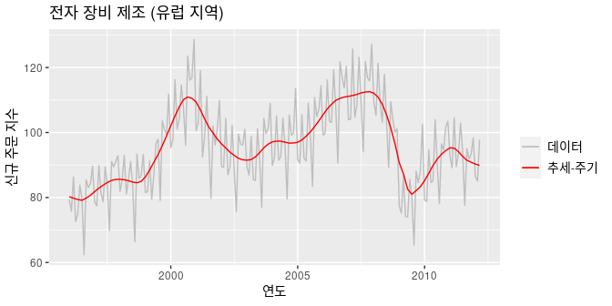

추세-주기 성분 $T_t$는 빨간색, 원본 데이터 $y_t$는 회색입니다. 계절성과 작은 무작위적 변동(random fluctuation)을 무시하면, 추세-주기가 시계열의 전반적인 움직임을 나타냅니다.

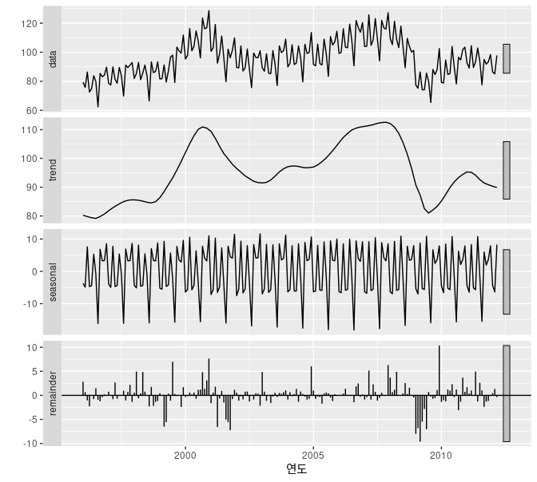

아래쪽 세 패널에 이 세 가지 성분을 각각 나타냈습니다. 이러한 성분은 모아서 더하면, 위쪽 패널에 나타낸 데이터를 재구성할 수 있습니다. **계절성분이 시간에 따라 느리게 변하여, 두 개의 연이은 연도가 비슷한 패턴을 갖고, 서로 멀리 떨어진 연도는 다른 계절성 패턴을 갖도록 한다는 것에 주목합시다.** 아래쪽 패널의 나머지 성분은 계절과 추세-주기 성분을 데이터에서 뺀 나머지입니다.

각 패널의 오른쪽의 회색 막대는 성분의 상대적인 눈금을 나타냅니다. 각 회색 막대는 같은 길이를 나타내지만 세로축 눈금에 따라 각 그림에서 크기가 다르게 보입니다. **가장 아래 패널에서 큰 회색 막대는 나머지 성분의 변동이 데이터에서 나타나는 변동보다 약 1/4 정도로 작다는 것을 나타냅니다. 아래에서부터 3개의 패널에서 나타나는 회색 막대를 데이터 패널에서 나타나는 것과 같게 맞추면, 모든 패널은 같은 눈금으로 나타날 것입니다.**

### 계절성으로 조정된 데이터

원본 데이터에서 계절성분을 제거한 결과 값을 “계절성으로 조정된(seasonally adjusted)” 데이터라고 부릅니다. **덧셈 분해에서, 계절성으로 조정된 데이터는 $y_{t}-S_{t}$로 주어지고, 곱셈 분해에서는 $y_{t}/S_{t}$을 이용하여 계절성으로 조정된 값을 구합니다.**

**계절성에 의한 변동이 주된 관심사가 아니라면, 계절성으로 조정된 시계열은 유용할 수 있습니다.** 예를 들면, 보통 월별 실업률 데이터를 다룰 때 계절성 변동보다는 중요한 경제 상황 때문에 나타나는 변동을 강조하기 위해 데이터를 계절성으로 조정합니다. 학교를 졸업한 사람들이 일자리를 찾는 것 때문에 나타나는 실업률 증가는 계절성 변동입니다만, 경기 침체 때문에 실업자가 많아서 생기는 증가는 비-계절성입니다. 실업률 데이터를 연구하는 대부분의 사람들은 비-계절성 변동에 관심이 많습니다. 따라서, 실업률 데이터(와 다른 많은 경제 분야 시계열)을 주로 계절성으로 조정하여 다룹니다.

계절성으로 조정된 시계열에는 추세-주기 성분도 있고 나머지 성분도 있습니다. 그래서, 시계열이 “매끄럽지” 않고, “하락세”나 “상승세”라는 표현이 오해를 불러 일으킬 수 있습니다. **시계열에서 전환점을 살펴보는 것과 어떤 방향으로의 변화를 해석하려는 것이 목적이라면, 계절성으로 조정된 데이터보다는 추세-주기 성분을 사용하는 것이 더 낫습니다.**

## 06.02. 이동평균

고전적인 시계열 분해 기법은 1920년까지 거슬러 올라가며, 1950년대까지 널리 사용되었습니다. 이 방법은 후대의 시계열 분석 기법의 기초가 되고 있기 때문에, 이 방법이 어떻게 작동하는지 잘 이해하는 것은 중요합니다. 고전적인 분해 방법의 첫 번째 단계는 추세-주기를 측정하기 위해 이동평균(moving average) 방법을 사용하는 것이니, 이동평균을 다루며 논의를 시작합니다.

### 이동 평균 평활

차수(order) $m$ 의 이동 평균은 다음과 같이 쓸 수 있습니다.

$$\begin{equation} \hat{T}_{t} = \frac{1}{m} \sum_{j=-k}^k y_{t+j}, \ \end{equation}$$

여기에서 $m=2k+1$입니다. **즉, $k$ 기간 안의 시계열 값을 평균하여 시간 $t$의 추세-주기를 측정합니다.** 측정 시기가 비슷하면 값도 비슷하기도 합니다. 따라서 평균이 데이터의 무작위성을 줄이고 매끄러운 추세-주기 성분만 남깁니다. 이것을 차수 $m$의 이동 평균이라는 의미에서 $“m -MA”$ 라고 부릅니다.

```r
library(tidyverse)
library(fpp3)
library(fpp2)
library(fpp)
library(forecast)
```

```r
elecsales %>% head
```

A Time Series:

1. 2354.34

2. 2379.71

3. 2318.52

4. 2468.99

5. 2386.09

6. 2569.47

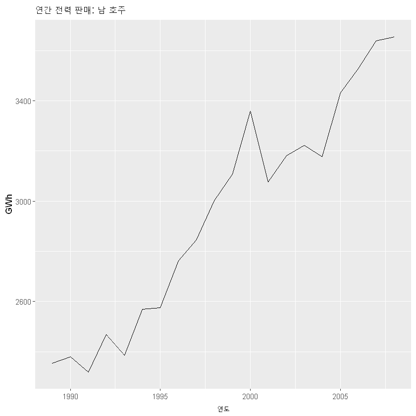

```r
autoplot(elecsales) + xlab("연도") + ylab("GWh") +
  ggtitle("연간 전력 판매: 남 호주")
```

Table 6.1: 남 호주 지역 연간 주거용 전력 판매량. 1989–2008.

| 연도 | 판매량 (GWh) | 5-MA |
| --- | --- | --- |
| 1989 | 2354.34 |  |
| 1990 | 2379.71 |  |
| 1991 | 2318.52 | 2381.53 |
| 1992 | 2468.99 | 2424.56 |
| 1993 | 2386.09 | 2463.76 |
| 1994 | 2569.47 | 2552.60 |
| 1995 | 2575.72 | 2627.70 |
| 1996 | 2762.72 | 2750.62 |
| 1997 | 2844.50 | 2858.35 |
| 1998 | 3000.70 | 3014.70 |
| 1999 | 3108.10 | 3077.30 |
| 2000 | 3357.50 | 3144.52 |
| 2001 | 3075.70 | 3188.70 |
| 2002 | 3180.60 | 3202.32 |
| 2003 | 3221.60 | 3216.94 |
| 2004 | 3176.20 | 3307.30 |
| 2005 | 3430.60 | 3398.75 |
| 2006 | 3527.48 | 3485.43 |
| 2007 | 3637.89 |  |
| 2008 | 3655.00 |  |

```r
ma(elecsales, 5)
```

A Time Series:

1. <NA>

2. <NA>

3. 2381.53

4. 2424.556

5. 2463.758

6. 2552.598

7. 2627.7

8. 2750.622

9. 2858.348

10. 3014.704

11. 3077.3

12. 3144.52

13. 3188.7

14. 3202.32

15. 3216.94

16. 3307.296

17. 3398.754

18. 3485.434

19. <NA>

20. <NA>

첫 2개의 연도와 마지막 2개 연도에서는 평균을 계산하기 위한 관측값이 부족해서 값이 없습니다. 뒷 부분에서 끝부분 근처의 추정값을 허용하는 더 정교한 추세-주기 추정 기법을 사용할 것입니다.

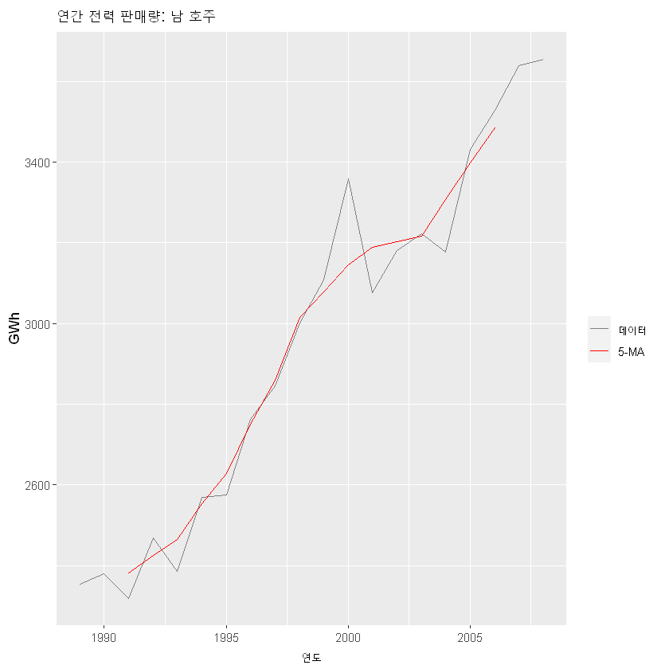

```r
autoplot(elecsales, series="데이터") +
  autolayer(ma(elecsales,5), series="5-MA") +
  xlab("연도") + ylab("GWh") +
  ggtitle("연간 전력 판매량: 남 호주") +
  scale_colour_manual(values=c("데이터"="grey50","5-MA"="red"),
                      breaks=c("데이터","5-MA")) +
  guides(colour=guide_legend(title=" "))
```

추세(빨간색)가 원본 데이터보다 얼마나 더 매끄러운지와 부가적인 변동을 제외한 시계열의 주된 움직임을 어떻게 포착하는지 주목합시다. **이동평균(moving average)의 차수(order)는 추세-주기 추정치의 매끄러운 정도를 결정합니다. 일반적으로, 더 큰 차수가 더 매끄러운 곡선을 의미합니다.**

단순 이동평균(moving average)은 보통 3,5,7 같은 홀수 차수(order)입니다. 그래서 이 방법은 대칭적입니다. 즉, $m=2k+1$ 차수의 이동평균에서는 가운데 값과 양쪽에서 각각 $k$개의 관측값을 평균합니다. $m$이 짝수이면, 더이상 대칭적이지 않을 것입니다.

- 데이터에서 이동 평균의 차수가 바뀔 때 일어나는 효과

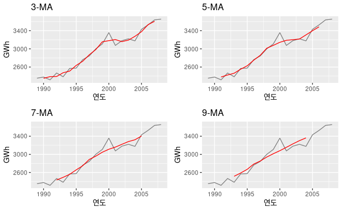

### 이동평균의 이동평균

동평균값을 또다시 이동평균할 수 있습니다. **짝수 차수 이동 평균을 대칭적으로 만들기 위해서 이러한 작업을 합니다.**

예를 들어, 차수 4의 이동 평균을 구한다고 하고, 그 다음 그 결과를 가지고 차수 2의 이동 평균을 구한다고 합시다. 호주 4분기별 맥주 생산량 처음 몇 년 데이터를 가지고 이러한 작업을 하여 다음의 표에 나타내었습니다.

- R에서 `ma()` 함수는 (`center=FALSE`로 정한 경우가 아니라면) 짝수 차수에 대한 중심화된 이동평균(centered moving average)을 돌려주는 것이 기본값

```r
beer2 <- window(ausbeer,start=1992)
length(beer2)
ma4 <- ma(beer2, order=4, centre=FALSE)
length(ma4 %>% na.omit)
ma2x4 <- ma(beer2, order=4, centre=TRUE)
length(ma2x4 %>% na.omit)
```

67

64

63

Table 6.2: 4차 이동평균을 구한 후에, 2차 이동평균을 분기별 백주 데이터에 적용한 것.

| 연도 | 분기 | 관측값 | 4-MA | 2x4-MA |
| --- | --- | --- | --- | --- |
| 1992 | Q1 | 443 |  |  |
| 1992 | Q2 | 410 | 451.25 |  |
| 1992 | Q3 | 420 | 448.75 | 450.00 |
| 1992 | Q4 | 532 | 451.50 | 450.12 |
| 1993 | Q1 | 433 | 449.00 | 450.25 |
| 1993 | Q2 | 421 | 444.00 | 446.50 |
| 1993 | Q3 | 410 | 448.00 | 446.00 |
| 1993 | Q4 | 512 | 438.00 | 443.00 |
| 1994 | Q1 | 449 | 441.25 | 439.62 |
| 1994 | Q2 | 381 | 446.00 | 443.62 |
| 1994 | Q3 | 423 | 440.25 | 443.12 |
| 1994 | Q4 | 531 | 447.00 | 443.62 |
| 1995 | Q1 | 426 | 445.25 | 446.12 |
| 1995 | Q2 | 408 | 442.50 | 443.88 |
| 1995 | Q3 | 416 | 438.25 | 440.38 |
| 1995 | Q4 | 520 | 435.75 | 437.00 |
| 1996 | Q1 | 409 | 431.25 | 433.50 |
| 1996 | Q2 | 398 | 428.00 | 429.62 |
| 1996 | Q3 | 398 | 433.75 | 430.88 |
| 1996 | Q4 | 507 | 433.75 | 433.75 |

마지막 열의 $“2×4 -MA”$는 4-MA 를 구하고나서 2-MA를 구했다는 의미입니다. 마지막 열의 값은 이전 열에 있는 값을 가지고 차수 2인 이동평균을 계산하여 구한 것입니다.

예를 들면, 4-MA 열의 첫 두 값은 $451.25=(443+410+420+532)/4$ 와 $448.75=(410+420+532+433)/4$입니다. $2×4-MA$ 열의 첫 번째 값은 이 두 값의 평균입니다: $450.00=(451.25+448.75)/2$.

2-MA가 (예로 든 4와 같이) 짝수 차수 이동평균 다음에 오면, “차수 4의 중심화된 이동평균(centred moving average of order 4)”이라고 부릅니다. 결과가 대칭적이기 때문에 이렇게 부릅니다. 이것이 대칭적인지 살펴보기 위해, $2×4-MA$를 다음과 같이 쓸 수 있습니다.

$$\begin{align*} \hat{T}_{t} &= \frac{1}{2}\Big[ \frac{1}{4} (y_{t-2}+y_{t-1}+y_{t}+y_{t+1}) + \frac{1}{4} (y_{t-1}+y_{t}+y_{t+1}+y_{t+2})\Big] \\ &= \frac{1}{8}y_{t-2}+\frac14y_{t-1} + \frac14y_{t}+\frac14y_{t+1}+\frac18y_{t+2}. \end{align*}$$

다른 이동평균 조합도 물론 가능합니다. 예를 들면, 차수 3의 이동평균 다음에 차수 3의 이동 평균을 구하는 $3×3-MA$도 종종 사용합니다. **일반적으로, 짝수 차수 MA를 대칭적으로 만들기 위해 짝수 차수 MA를 그 다음에 사용해야 합니다. 비슷한 이유에서, 홀수 차수 MA 다음에, 홀수 차수 MA를 사용해야 합니다.**

### 계절성 데이터에서 추세-주기를 측정하기

**중심화된 이동평균(centred moving average)의 주 용도는 계절성 데이터에서 추세-주기(trend-cycle)를 측정하는 것입니다.** $2×4 -MA$를 살펴봅시다

$$\hat{T}_{t} = \frac{1}{8}y_{t-2} + \frac14y_{t-1} + \frac14y_{t} + \frac14y_{t+1} + \frac18y_{t+2}.$$

분기별 데이터에 적용하면, 첫 번째와 마지막 항이 앞뒤 연도의 영향을 받아서 한 해의 각 분기에 같은 가중치가 주어집니다. 그 결과로, 평균 때문에 계절성 변동이 사라지게 되고, 결과값 $\hat{T}_t$에 계절적인 변동이 별로 남지 않게 됩니다. 분기별 데이터에 $2×8 -MA$ 이나 $2×12 -MA$ 를 사용해도 비슷한 결과를 얻게 됩니다.

**일반적으로 $2×m -MA$은 $m+1$ 차수의 가중 이동평균(weighted moving avverage)과 같습니다. 여기에서 첫 번째와 마지막 값을 제외한 모든 관측값에는 $1/m$ 가중치를 두고 계산하고, 첫 번째와 마지막 값에는 $1/(2m)$의 가중치를 두고 계산합니다.**

흔히 다른 차수의 MA를 사용하면 데이터의 계절성 때문에 추세-주기 측정이 정확하지 않게 됩니다.

### 예제: 전자 장비 제조

전자 장비 제조 지수에 $2×12 -MA$ 를 적용한 결과입니다. **매끄러운 선에서 계절성이 보이지 않는다는 것에 주목합시다.** 그림의 이동평균(moving average)보다 훨씬 더 복잡한 방법으로 측정한 추세-주기(trend-cycle)와 거의 같습니다.

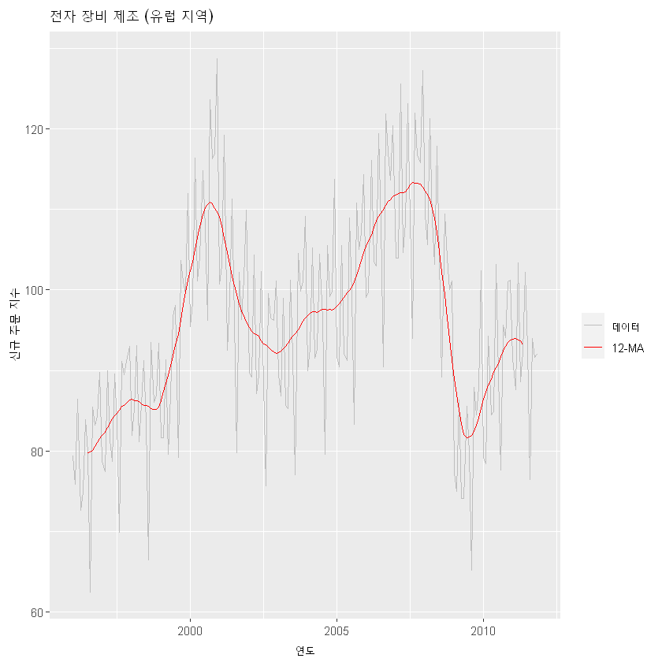

```r
autoplot(elecequip, series="데이터") +
  autolayer(ma(elecequip, 12), series="12-MA") +
  xlab("연도") + ylab("신규 주문 지수") +
  ggtitle("전자 장비 제조 (유럽 지역)") +
  scale_colour_manual(values=c("데이터"="grey","12-MA"="red"),
                      breaks=c("데이터","12-MA")) +
  guides(colour=guide_legend(title=" "))
```

**이동 평균의 차수를 낮은 값으로 선택하면 어떤 계절성 요동을 약간 나타내는 매끄러운 선을 얻을 것입니다.**

[figure not shown]

```r
autoplot(elecequip, series="데이터") +
  autolayer(ma(elecequip, 4), series="12-MA") +
  xlab("연도") + ylab("신규 주문 지수") +
  ggtitle("전자 장비 제조 (유럽 지역)") +
  scale_colour_manual(values=c("데이터"="grey","12-MA"="red"),
                      breaks=c("데이터","12-MA")) +
  guides(colour=guide_legend(title=" "))
```

### 가중 이동평균

이동평균의 조합이 가중 이동평균(weighted moving average)이 되는 것을 확인했습니다. 예를 들면, **위에서 언급한 $2×4-MA$ 는 가중치를 다음과 같이 주는 가중 5-MA와 같습니다.**

$$\left[\frac{1}{8},\frac{1}{4},\frac{1}{4},\frac{1}{4},\frac{1}{8}\right]$$

일반적으로, 가중 $m -MA$는 다음과 같이 쓸 수 있습니다.

$$\hat{T}_t = \sum_{j=-k}^k a_j y_{t+j},$$

**여기에서 $k=(m-1)/2$이고, 가중치는 $\left[a_{-k},\dots,a_k\right]$로 주어집니다. 가중치를 모두 더하면 1이고 가중치들은 $a_j = a_{-j}$와 같이 대칭적입니다. 단순 $m -MA$는 모든 가중치를 $1/m$으로 같게 둔 특별한 경우입니다.**

**더욱 매끄러운 추세-주기(trend-cycle)를 얻을 수 있다는 점이 가중평균(weighted average)의 주된 장점입니다. 관측값에 가중치를 전부 고려하지 않고, 천천히 증가하다가 감소하는 가중치를 이용하여 더 매끄러운 곡선을 구합니다.**

## 06.03. 고전적인 분해법

고전적인 분해 기법은 1920년대에 창안되었습니다. 단순한 편이고 대부분의 다른 시계열 분해 방법의 기초가 됩니다. 고전적인 분해법에는 덧셈 분해와 곱셈 분해 이렇게 두 가지 형태가 있습니다.

**아래는 주기 $m$ 이 있는 시계열입니다(즉, 분기별 데이터에서는 $m=4$, 월별 데이터에서는 $m=12$, 주별 패턴이 있는 일별 데이터에서는 $m=7$ 입니다).**

**여기에서 고전적인 분해를 다룰 때는 계절적인 성분이 매년 일정하다고 가정합니다. 때때로 곱셈 계절성에서는 계절성분을 구성하는 $m$값을 “계절성 지수(seasonal indices)”라고 부릅니다.**

### 덧셈 분해

#### 1단계

**$m$이 짝수이면, $2×m-MA$를 사용하여 추세-주기 성분 $\hat{T}_t$을 계산합니다. $m$이 홀수이면, $m-MA$를 사용하여 추세-주기 성분 $\hat{T}_t$을 계산합니다.**

#### 2단계

**다음과 같이 추세를 제거한 시계열을 계산합니다: $y_t - \hat{T}_t$**

#### 3단계

**각 계절마다 계절성분을 측정하기 위해, 해당 계절에 대해 추세를 제거한 값의 평균을 구합시다.**

**예를 들면, 월별 데이터에서 3월의 계절성분은 데이터에서 추세를 제거한 모든 3월 값의 평균입니다. 그러면 이러한 계절성분 값이 0 근처의 값이 되도록 조정됩니다. 이러한 월별 값을 순서대로 모으고 각 연도의 데이터에 대한 수열을 복제하여 계절성분을 구합니다. 이렇게 $\hat{S}_t$을 얻습니다.**

#### 4단계

**다음과 같이 측정한 계절성과 추세-주기 성분을 빼서 나머지 성분을 계산합니다: $\hat{R}_t = y_t - \hat{T}_t - \hat{S}_t$**

### 곱셈 분해

**고전적인 곱셈 분해법은 뺄셈을 나눗셈으로 바꾼 것만 제외하면 덧셈 분해법과 비슷합니다.**

#### 1단계

**$m$이 짝수이면, $2×m-MA$를 사용하여 추세-주기 성분 $\hat{T}_t$을 계산합니다. $m$이 홀수이면, $m-MA$를 사용하여 추세-주기 성분 $\hat{T}_t$을 계산합니다.**

#### 2단계

**다음과 같이 추세를 제거한 시계열을 계산합니다: $y_t / {T}_t$**

#### 3단계

**각 계절마다 계절성분을 측정하기 위해, 해당 계절에 대해 추세를 제거한 값의 평균을 구합시다.**

#### 4단계

**다음과 같이 측정한 계절성과 추세-주기 성분을 빼서 나머지 성분을 계산합니다: $\hat{R}_{t} = y_t /( \hat{T}_t \hat{S}_t)$**

- 전자 장비 지수를 고전적으로 분해
- **2009년에서 1보다 작은 나머지 값이 추세-주기 성분에서 어떤 부분이 나머지 성분으로 “유출”되었다고 말해줍니다. 추세-주기 측정으로 데이터에서 나타나는 이러한 감소가 묻히고, 해당 나머지 값은 나쁜 추세-주기 측정에 영향을 받았습니다.**

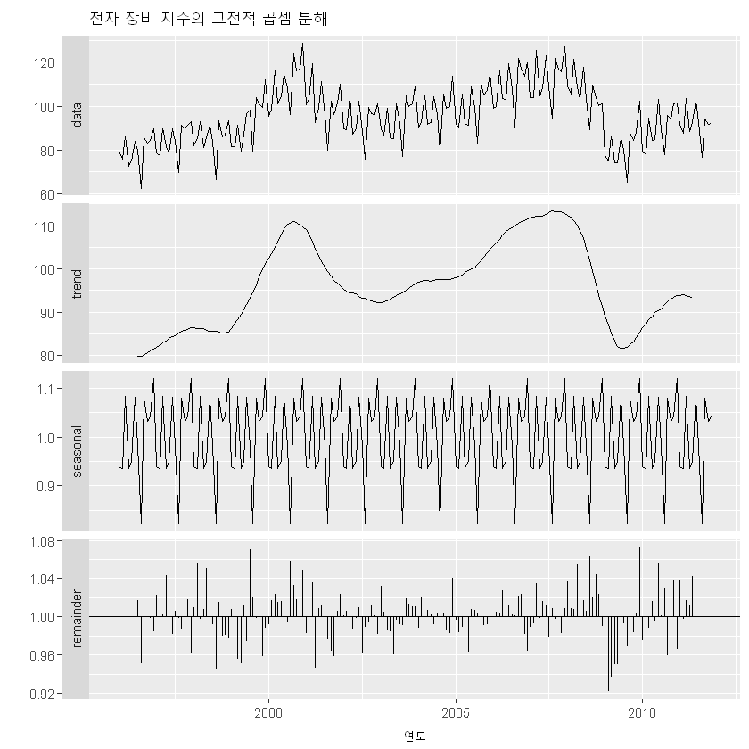

```r
elecequip %>% decompose(type="multiplicative") %>%
  autoplot() + xlab("연도") +
  ggtitle("전자 장비 지수의 고전적 곱셈 분해")
```

### 고전적인 분해에 대한 첨언

고전적인 분해법이 여전히 널리 사용되고 있지만, 추천하는 방법은 아닙니다. 왜냐하면 이제 훨씬 더 나은 기법이 존재하기 때문입니다. 고전적인 분해법으로 다룰 때의 몇 가지 문제점을 아래에 요약하였습니다.

- **처음 몇 개와 마지막 몇 개의 관측값에 대한 추세 추정값을 얻을 수 없습니다.** 예를 들면, $m=12$일 때, 처음 여섯개와 마지막 여섯개 관측값에 대한 추세 추정값은 존재하지 않습니다. 결과적으로, 같은 기간에 대해 나머지 성분을 측정하는 것도 불가능합니다.
- 추세-주기 측정은 (위의 예제에서 처럼) 데이터에 나타나는 급격한 증가나 감소를 과도하게 매끄럽게 합니다.
- **고전적인 분해법은 계절성분이 매년 반복된다는 것을 가정합니다.** 많은 시계열에서, 이렇게 가정하는 것이 나름 합리적입니다만, 몇몇 더 긴 시계열에 대해서는 그렇지 않습니다. 예를 들면, 전기 수요 패턴은 에어컨이 더욱 보급되면서 시간에 따라 변했습니다. 따라서 많은 지역에서 현재 계절적인 패턴에서 최대 수요 값이 에어컨 때문에 여름에 나타나지만, 수십년 전에는 난방 때문에 겨울에 나타났습니다. **고전적인 분해 기법으로는 이러한 시간적으로 변하는 계절적인 변화를 다룰 수 없습니다.**
- **가끔 짧은 기간의 시계열 값이 특별히 이상할 수 있습니다.** 예를 들면, 월별 항공 탑승자 수는 노사분규에 영향을 받을 수 있고 분쟁 기간 동안 평소보다 특이한 패턴이 나타날 수 있습니다. 고전적인 방법은 이러한 종류의 특이한 값을 다루기에 적절하지 않습니다.